# JDMisc functions

Authors

Josh DeClercq

Department of Biostatistics

Vanderbilt University Medical Center

Published

February 2, 2024

# 1 Objective

## 1.1 Background

Throughout my time as a biostatistician in the department, I’ve developed a handful of convenience functions. I think they’re useful in my day-to-day work, and I think they can be useful for others. However, I usually write code in a way that’s easy for me to understand, but my style unlikely follows best-practice guidelines, and there is potentially a lot of issues that may arise. This document will show the ideal use cases for these functions.

## 1.2 Goals

The goal of this document is to showcase some of this work, and to use it as a springboard into the development of a collaborative R package, wherein all members of the VUMC Department of Biostatistics can contribute functions to a central repository. Sharing code amongst the department should conceivably increase our individual coding skills as well as productivity.

This work is hosted on my [Github](https://github.com/jjdeclercq/VUMisC), but I would eagerly transfer ownership rights to anyone who is willing. (My git knowledge is quite limited at the moment.)

## 1.3 Data

This report uses the `titanic3` data. This report isn’t intended to be a description of the best way to analyze this data.

```r
# Retreive data
getHdata(titanic3)

t3 <- titanic3 %>%
  select(-c( boat:home.dest, ticket)) %>%
  mutate(id = 1:n()) ## Create a unique ID variable for each row

archive(t3) ## this will be discussed later, but essentially this takes an impression of the current data for later use
```

```
[1] "No changes made to data"
```

```r
# Data cleaning/ Create new variables
t3 %<>% mutate(cabin = as.character(cabin), cabin = ifelse(cabin == "", NA, cabin))
t3 %<>% mutate(s.cat = yesno(survived == 1))
t3 %<>% mutate(missing.age = yesno(is.na(age)))
```

# 2 Labels

## 2.1 Clear labels

```r
t3 %<>% clear.labels()
```

## 2.2 Adding labels

`j.label5()` is code that outputs text suitable for pasting into your markdown document.

```r
j.label5(t3)
```

```
t3 <- labelVector::set_label( t3 ,
        pclass = "",
        survived = "",
        name = "",
        sex = "",
        age = "",
        sibsp = "",
        parch = "",
        fare = "",
        cabin = "",
        embarked = "",
        id = "",
        s.cat = "",
        missing.age = "")
```

Labels can then be filled in by hand.

```r
t3 <- labelVector::set_label( t3 ,
                 name = "Passenger name",
                     pclass = 'Passenger class',
                 survived = 'Survived',
                 sex = 'Sex',
                 age = 'Age',
                 sibsp = 'Number of Siblings/Spouses Aboard',
                 parch = 'Number of Parents/Children Aboard',
                 fare = 'Passenger Fare',
                 embarked = 'Port of Embarkation',
                 cabin = "Cabin")
```

Subsequent execution of the code will have the added labels incorporated. Toggling the `all` argument determines whether all variables will be displayed or just those without labels

```r
j.label5(t3, all = TRUE)
```

```
t3 <- labelVector::set_label( t3 ,
        pclass = "Passenger class",
        survived = "Survived",
        name = "Passenger name",
        sex = "Sex",
        age = "Age",
        sibsp = "Number of Siblings/Spouses Aboard",
        parch = "Number of Parents/Children Aboard",
        fare = "Passenger Fare",
        cabin = "Cabin",
        embarked = "Port of Embarkation",
        id = "",
        s.cat = "",
        missing.age = "")
```

```r
j.label5(t3, all = FALSE)
```

```
t3 <- labelVector::set_label( t3 ,
        id = "",
        s.cat = "",
        missing.age = "")
```

```r
t3 <- labelVector::set_label( t3 ,
        s.cat = "Survived",
        missing.age = "Missing age")
```

## 2.3 Collect labels

Create a data frame of variable names and the corresponding label.

```r
collect.labels(t3)
```

```
      variable                             label
1       pclass                   Passenger class
2     survived                          Survived
3         name                    Passenger name
4          sex                               Sex
5          age                               Age
6        sibsp Number of Siblings/Spouses Aboard
7        parch Number of Parents/Children Aboard
8         fare                    Passenger Fare
9        cabin                             Cabin
10    embarked               Port of Embarkation
11          id
12       s.cat                          Survived
13 missing.age                       Missing age
```

## 2.4 Removing labels

Sometimes labelled data can present challenges as shown by the example below:

```r
t3 %>% select(name, age, sibsp) %>%
  pivot_longer(., -1, names_to = "var")
```

```
Error in `pivot_longer()`:
! Can't combine `age` <labelled> and `sibsp` <labelled>.
✖ Some attributes are incompatible.
ℹ The author of the class should implement vctrs methods.
ℹ See <https://vctrs.r-lib.org/reference/faq-error-incompatible-attributes.html>.
Backtrace:
 1. t3 %>% select(name, age, sibsp) %>% ...
 3. tidyr:::pivot_longer.data.frame(., -1, names_to = "var")
```

`clear.labels`

I did not write this function ([stackoverflow](https://stackoverflow.com/questions/2394902/remove-variable-labels-attached-with-foreign-hmisc-spss-import-functions)) but I find it immensely helpful in removing all labels from a data frame.

```r
t3.labelled <- t3 ## create a second data frame for regaining labels later
t3 <- clear.labels(t3)


t3 %>% select(name, age, sibsp) %>% pivot_longer(., -1, names_to = "var") %>% head()
```

```
# A tibble: 6 × 3
  name                           var    value
  <chr>                          <chr>  <dbl>
1 Allen, Miss. Elisabeth Walton  age   29
2 Allen, Miss. Elisabeth Walton  sibsp  0
3 Allison, Master. Hudson Trevor age    0.917
4 Allison, Master. Hudson Trevor sibsp  1
5 Allison, Miss. Helen Loraine   age    2
6 Allison, Miss. Helen Loraine   sibsp  1
```

## 2.5 Adding labels back

Not my function, but I find this to be very helpful.

```r
t3 <- sjlabelled::copy_labels(t3, t3.labelled)
```

`clear.label.class()` is a nice workaround for labelled data. It just removes the class “label” from the variable, but still retains the utility of labelled data.

```r
t3 <- clear.label.class(t3)
```

## 2.6 Clearing empty columns

Sometimes there are columns in the data that don’t carry any information. `remove.blank.columns2()` will remove all columns from the data that are either all `NA` or all empty characters (`""`).

```r
t3 %<>% mutate(x = "", y = NA, z= as.Date(NA))

t3 %>% select(x, y, z) %>% head(10)
```

```
   x  y    z
1    NA <NA>
2    NA <NA>
3    NA <NA>
4    NA <NA>
5    NA <NA>
6    NA <NA>
7    NA <NA>
8    NA <NA>
9    NA <NA>
10   NA <NA>
```

```r
t3 %<>% remove.blank.columns2()
```

```r
names(t3)
```

```
 [1] "pclass"      "survived"    "name"        "sex"         "age"
 [6] "sibsp"       "parch"       "fare"        "cabin"       "embarked"
[11] "id"          "s.cat"       "missing.age"
```

# 3 Factors

## 3.1 label_factor

Produces code that can be pasted into your report for adding in variable labels:

```r
label_factor(t3, "sex")
```

```
t3 <- within( t3 ,{
 sex %<>% factor(., levels = c('female','male'), labels = c( ))
 })
```

Can accommodate any number of factor variables:

```r
t3 %>% select(where(is.factor)) %>%
  names() %>%
  label_factor(t3, .)
```

```
t3 <- within( t3 ,{
 pclass %<>% factor(., levels = c('1st','2nd','3rd'), labels = c( ))
 sex %<>% factor(., levels = c('female','male'), labels = c( ))
 embarked %<>% factor(., levels = c('Cherbourg','Queenstown','Southampton'), labels = c( ))
 })
```

## 3.2 recode_factor

Produce editable code using `forcats::fct_recode()`

```r
recode_factor(t3, "embarked")
```

```
t3 %>% mutate(embarked = forcats::fct_recode(embarked,
            "" = "Cherbourg",
            "" = "Queenstown",
            "" = "Southampton"))
```

## 3.3 j.trib

Create an editable `tribble` table that can be joined back into original data frame.

```r
j.trib(t3, "embarked")
```

```
trib.t3<- tribble(~embarked, ~replace,
              'Cherbourg', '',
              'Queenstown', '',
              'Southampton', '',
              'NA', '')

 t3 %>% left_join(., trib.t3, by = 'embarked') %>% select(-embarked, embarked = replace)
```

```r
trib.t3<- tribble(~embarked, ~replace,
              'Cherbourg', '',
              'Queenstown', '',
              'Southampton', '',
              'NA', '')
```

# 4 Tables

## 4.1 jgt

The package `gtsummary` provides a lot of great functions for summarizing data. The `jgt()` is a wrapper for `tbl_summary` that handles 99% of summary tables that I need to make.

```r
t3 %>% select(age, sex, pclass, fare, embarked, sibsp, parch, s.cat) %>%
  jgt(., by = "s.cat", spanner.size = 2, spanner.text = "Survived", overall = TRUE)
```

| **Characteristic** | **N** | **Survived** **No**, N = 809<sup>1</sup> | **Survived** **Yes**, N = 500<sup>1</sup> | **Overall**, N = 1309<sup>1</sup> |  |
| --- | --- | --- | --- | --- | --- |
| Age | 1046 |  |  |  |  |
| Mean (SD) |  | 30.5 (13.9) | 28.9 (15.1) | 29.9 (14.4) |  |
| Median (IQR) |  | 28.0 (21.0 - 39.0) | 28.0 (20.0 - 38.0) | 28.0 (21.0 - 39.0) |  |
| Range |  | 0.3 - 74.0 | 0.2 - 80.0 | 0.2 - 80.0 |  |
| Missing |  | 190 | 73 | 263 |  |
| Sex | 1309 |  |  |  |  |
| female |  | 127 (15.7%) | 339 (67.8%) | 466 (35.6%) |  |
| male |  | 682 (84.3%) | 161 (32.2%) | 843 (64.4%) |  |
| Passenger class | 1309 |  |  |  |  |
| 1st |  | 123 (15.2%) | 200 (40.0%) | 323 (24.7%) |  |
| 2nd |  | 158 (19.5%) | 119 (23.8%) | 277 (21.2%) |  |
| 3rd |  | 528 (65.3%) | 181 (36.2%) | 709 (54.2%) |  |
| Passenger Fare | 1308 |  |  |  |  |
| Mean (SD) |  | 23.4 (34.1) | 49.4 (68.6) | 33.3 (51.8) |  |
| Median (IQR) |  | 10.5 (7.9 - 26.0) | 26.0 (11.2 - 57.8) | 14.5 (7.9 - 31.3) |  |
| Range |  | 0.0 - 263.0 | 0.0 - 512.3 | 0.0 - 512.3 |  |
| Missing |  | 1 | 0 | 1 |  |
| Port of Embarkation | 1307 |  |  |  |  |
| Cherbourg |  | 120 (14.8%) | 150 (30.1%) | 270 (20.7%) |  |
| Queenstown |  | 79 (9.77%) | 44 (8.84%) | 123 (9.41%) |  |
| Southampton |  | 610 (75.4%) | 304 (61.0%) | 914 (69.9%) |  |
| Missing |  | 0 | 2 | 2 |  |
| Number of Siblings/Spouses Aboard | 1309 |  |  |  |  |
| 0 |  | 582 (71.9%) | 309 (61.8%) | 891 (68.1%) |  |
| 1 |  | 156 (19.3%) | 163 (32.6%) | 319 (24.4%) |  |
| 2 |  | 23 (2.84%) | 19 (3.80%) | 42 (3.21%) |  |
| 3 |  | 14 (1.73%) | 6 (1.20%) | 20 (1.53%) |  |
| 4 |  | 19 (2.35%) | 3 (0.60%) | 22 (1.68%) |  |
| 5 |  | 6 (0.74%) | 0 (0%) | 6 (0.46%) |  |
| 8 |  | 9 (1.11%) | 0 (0%) | 9 (0.69%) |  |
| Number of Parents/Children Aboard | 1309 |  |  |  |  |
| 0 |  | 666 (82.3%) | 336 (67.2%) | 1002 (76.5%) |  |
| 1 |  | 70 (8.65%) | 100 (20.0%) | 170 (13.0%) |  |
| 2 |  | 56 (6.92%) | 57 (11.4%) | 113 (8.63%) |  |
| 3 |  | 3 (0.37%) | 5 (1.00%) | 8 (0.61%) |  |
| 4 |  | 5 (0.62%) | 1 (0.20%) | 6 (0.46%) |  |
| 5 |  | 5 (0.62%) | 1 (0.20%) | 6 (0.46%) |  |
| 6 |  | 2 (0.25%) | 0 (0%) | 2 (0.15%) |  |
| 9 |  | 2 (0.25%) | 0 (0%) | 2 (0.15%) |  |

<sup>1</sup> n (%)

## 4.2 jgtt

Simply prints the data using the `gt` package, and stylized to match `jgt` output.

```r
t3  %>% select(name, age, sex, pclass) %>% head(20) %>% jgtt()
```

| name | age | sex | pclass |
| --- | --- | --- | --- |
| Allen, Miss. Elisabeth Walton | 29.0000 | female | 1st |
| Allison, Master. Hudson Trevor | 0.9167 | male | 1st |
| Allison, Miss. Helen Loraine | 2.0000 | female | 1st |
| Allison, Mr. Hudson Joshua Crei | 30.0000 | male | 1st |
| Allison, Mrs. Hudson J C (Bessi | 25.0000 | female | 1st |
| Anderson, Mr. Harry | 48.0000 | male | 1st |
| Andrews, Miss. Kornelia Theodos | 63.0000 | female | 1st |
| Andrews, Mr. Thomas Jr | 39.0000 | male | 1st |
| Appleton, Mrs. Edward Dale (Cha | 53.0000 | female | 1st |
| Artagaveytia, Mr. Ramon | 71.0000 | male | 1st |
| Astor, Col. John Jacob | 47.0000 | male | 1st |
| Astor, Mrs. John Jacob (Madelei | 18.0000 | female | 1st |
| Aubart, Mme. Leontine Pauline | 24.0000 | female | 1st |
| Barber, Miss. Ellen \"Nellie\" | 26.0000 | female | 1st |
| Barkworth, Mr. Algernon Henry W | 80.0000 | male | 1st |
| Baumann, Mr. John D | NA | male | 1st |
| Baxter, Mr. Quigg Edmond | 24.0000 | male | 1st |
| Baxter, Mrs. James (Helene DeLa | 50.0000 | female | 1st |
| Bazzani, Miss. Albina | 32.0000 | female | 1st |
| Beattie, Mr. Thomson | 36.0000 | male | 1st |

## 4.3 j.reactable

Better at presenting lots of data: tabbed output, searchable text, filtering and embedding data as a csv file are available. The `reactable` package provides a ton a great functionality. `j.reactable` is a convenient wrapper that suits the majority of table needs.

```r
t3  %>% select(name, age, sex, pclass) %>%
  j.reactable(., csv.file = "titanic")
```

|  | Passenger name | Age | Sex | Passenger class |
| --- | --- | --- | --- | --- |
| 1 | Allen, Miss. Elisabeth Walton | 29 | female | 1st |
| 2 | Allison, Master. Hudson Trevor | 0.916700006 | male | 1st |
| 3 | Allison, Miss. Helen Loraine | 2 | female | 1st |
| 4 | Allison, Mr. Hudson Joshua Crei | 30 | male | 1st |
| 5 | Allison, Mrs. Hudson J C (Bessi | 25 | female | 1st |
| 6 | Anderson, Mr. Harry | 48 | male | 1st |
| 7 | Andrews, Miss. Kornelia Theodos | 63 | female | 1st |
| 8 | Andrews, Mr. Thomas Jr | 39 | male | 1st |
| 9 | Appleton, Mrs. Edward Dale (Cha | 53 | female | 1st |
| 10 | Artagaveytia, Mr. Ramon | 71 | male | 1st |

[output cut: 1299 more lines]

# 5 Dates

Create dummy data data using a Cauchy distribution to generate some obvious outliers.

```r
t3 %<>%
  mutate(date1 = ymd("1888-01-01") + days(floor(rcauchy((nrow(t3)), 0, 300))),
         date2 = ymd("1898-01-01") + days(floor(rcauchy((nrow(t3)), 0, 200))),
         date3 = ymd("1911-01-01") + days(floor(rnorm((nrow(t3)), 0, 202))),
         date4 = ymd("1853-01-01") + days(floor(rnorm((nrow(t3)), 0, 11))))

j.label5(t3)
```

```
t3 <- labelVector::set_label( t3 ,
        id = "",
        date1 = "",
        date2 = "",
        date3 = "",
        date4 = "")
```

```r
t3 <- set_label( t3 ,
        date1 = "Date of birth",
        date2 = "First time on boat",
        date3 = "Ticket purchase date",
        date4 = "Other date")
```

## 5.1 date_dists

### 5.1.1 Figure

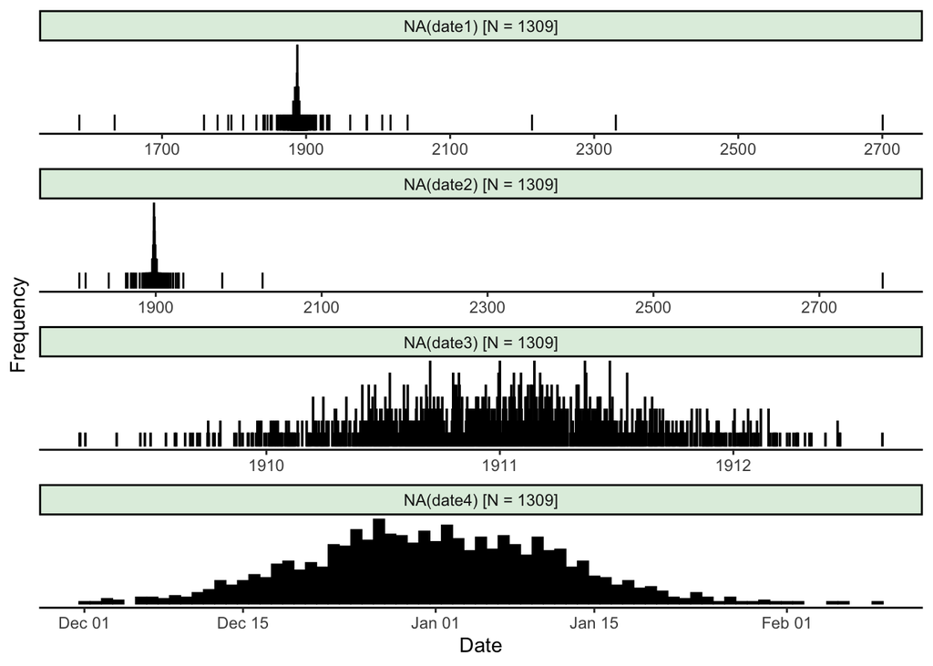

```r
t3_dates <- t3 %>%
  date_dists(., id.var = "id", label.src = t3.labelled)

ggplot(t3_dates, aes(x = value)) +
  geom_histogram(stat = "count", fill = "black", colour = "black", bins = 100) +
  theme_classic() +labs(x = "Date", y = "Frequency") +
  facet_wrap(variable~., scales = "free", ncol = 1)+
  theme(strip.background =element_rect(fill="honeydew2"),
        axis.text.y = element_blank(),
        axis.ticks.y = element_blank(),
        axis.line.y = element_blank())
```

### 5.1.2 Table

```r
t3_dates %>%
  select(variable, sequence, date, id) %>%
  na.omit() %>%
   j.reactable(., groupBy = c("variable"))
```

| variable | sequence | date | id |
| --- | --- | --- | --- |
| NA(date1) [N = 1309] | 1 | 1585-02-17 | 419 |
| NA(date1) [N = 1309] | 2 | 1634-02-28 | 832 |
| NA(date1) [N = 1309] | 3 | 1758-04-17 | 198 |
| NA(date1) [N = 1309] | 4 | 1777-01-22 | 485 |
| NA(date1) [N = 1309] | 5 | 1791-12-06 | 418 |
| NA(date1) [N = 1309] | 6 | 1796-04-12 | 353 |
| NA(date1) [N = 1309] | 7 | 1812-08-31 | 487 |
| NA(date1) [N = 1309] | 8 | 1831-01-02 | 646 |
| NA(date1) [N = 1309] | 9 | 1840-09-20 | 1267 |
| NA(date1) [N = 1309] | 10 | 1842-09-30 | 144 |

[output cut: 70 more lines]

# 6 Analysis

## 6.1 rms.trib

```r
dd <- datadist(t3)
options(datadist = "dd", prType = "html", grType='plotly')
t3.mod <- lrm(s.cat ~ rcs(age, 5) + sex  + pclass + embarked + sibsp, data = t3)
t3.mod.int <- lrm(s.cat ~ rcs(age, 5) * sex  + pclass + embarked + sibsp, data = t3)
rms.trib(t3.mod)
```

```
trib.cols.rms <- tribble(~term, ~new, ~level, ~label,
             'age', 'Age', '1', 'Age',
             'sex', 'sex', '2', 'sex',
             'pclass', 'pclass', '3', 'pclass',
             'embarked', 'embarked', '4', 'embarked',
             'sibsp', 'sibsp', '5', 'sibsp')
```

```r
trib.cols.rms <- tibble::tribble(
       ~term,               ~new, ~level,                              ~label,
       "age",              "Age",    "1",                               "Age",
       "sex",              "Sex",    "2",                               "Sex",
    "pclass",  "Passenger class",    "5",                   "Passenger class",
  "embarked",             "Port",    "3",               "Port of Embarkation",
     "sibsp", "Siblings/Spouses",    "4", "Number of Siblings/Spouses Aboard"
  )
```

## 6.2 rms.sum.table3

```r
rms.sum.table3(summary = summary(t3.mod), trib.cols.rms, raw = TRUE)
```

```
# A tibble: 7 × 16
  term   highc lowc  type  diff  effect std.error conf.low conf.high vt    new
  <chr>  <chr> <chr> <chr> <smm> <smmr> <smmry.r> <smmry.> <smmry.r> <chr> <chr>
1 age    39    21    ratio 18     0.75… NA         0.4780…  1.176919 Cont… Age
2 sex    fema… male  ratio NA    14.53… NA        10.2389… 20.635641 Cate… Sex
3 embar… Cher… Sout… ratio NA     1.95… NA         1.2845…  2.974838 Cate… Port
4 embar… Quee… Sout… ratio NA     0.47… NA         0.2125…  1.041015 Cate… Port
5 sibsp  1     0     ratio  1     0.64… NA         0.5214…  0.805072 Cont… Sibl…
6 pclass 1st   3rd   ratio NA     7.34… NA         4.5951… 11.732873 Cate… Pass…
7 pclass 2nd   3rd   ratio NA     2.43… NA         1.6261…  3.650921 Cate… Pass…
# ℹ 5 more variables: level <chr>, label <chr>, facet <fct>, axis <chr>,
#   levels <chr>
```

```r
rms.sum.table3(summary = summary(t3.mod), trib.cols.rms, anova(t3.mod))
```

| label | levels | effect | conf.low | conf.high | d.f. | P |
| --- | --- | --- | --- | --- | --- | --- |
| Age | 39 vs. 21 | 0.750 | 0.478 | 1.177 | 4 | <0.001 |
| Sex | female vs. male | 14.536 | 10.239 | 20.636 | 1 | <0.001 |
| Port of Embarkation | Cherbourg vs. Southampton | 1.955 | 1.285 | 2.975 | 2 | <0.001 |
| Port of Embarkation | Queenstown vs. Southampton | 0.470 | 0.213 | 1.041 | 2 | <0.001 |
| Number of Siblings/Spouses Aboard | 1 vs. 0 | 0.648 | 0.521 | 0.805 | 1 | <0.001 |
| Passenger class | 1st vs. 3rd | 7.343 | 4.595 | 11.733 | 2 | <0.001 |
| Passenger class | 2nd vs. 3rd | 2.437 | 1.626 | 3.651 | 2 | <0.001 |

```r
rms.sum.table3(summary = summary(t3.mod.int), trib.cols.rms, anova = anova(t3.mod.int))
```

| label | levels | effect | conf.low | conf.high | d.f. | P |
| --- | --- | --- | --- | --- | --- | --- |
| Age | 39 vs. 21 | 0.634 | 0.343 | 1.171 | NA | NA |
| Sex | female vs. male | 13.486 | 7.112 | 25.573 | NA | NA |
| Port of Embarkation | Cherbourg vs. Southampton | 2.064 | 1.341 | 3.177 | 2 | <0.001 |
| Port of Embarkation | Queenstown vs. Southampton | 0.439 | 0.197 | 0.975 | 2 | <0.001 |
| Number of Siblings/Spouses Aboard | 1 vs. 0 | 0.636 | 0.514 | 0.787 | 1 | <0.001 |
| Passenger class | 1st vs. 3rd | 7.788 | 4.762 | 12.736 | 2 | <0.001 |
| Passenger class | 2nd vs. 3rd | 2.323 | 1.542 | 3.499 | 2 | <0.001 |

Interaction terms adjusted to: Age: 28; Sex: male

```r
rms.sum.table3(summary = summary(t3.mod.int, age = c(25, 50, 75), sex = "female"),
               trib.cols.rms, anova = anova(t3.mod.int))
```

| label | levels | effect | conf.low | conf.high | d.f. | P |
| --- | --- | --- | --- | --- | --- | --- |
| Age | 75 vs. 25 | 0.776 | 0.065 | 9.274 | NA | NA |
| Sex | male vs. female | 0.024 | 0.011 | 0.053 | NA | NA |
| Port of Embarkation | Cherbourg vs. Southampton | 2.064 | 1.341 | 3.177 | 2 | <0.001 |
| Port of Embarkation | Queenstown vs. Southampton | 0.439 | 0.197 | 0.975 | 2 | <0.001 |
| Number of Siblings/Spouses Aboard | 1 vs. 0 | 0.636 | 0.514 | 0.787 | 1 | <0.001 |
| Passenger class | 1st vs. 3rd | 7.788 | 4.762 | 12.736 | 2 | <0.001 |
| Passenger class | 2nd vs. 3rd | 2.323 | 1.542 | 3.499 | 2 | <0.001 |

Interaction terms adjusted to: Age: 50; Sex: female

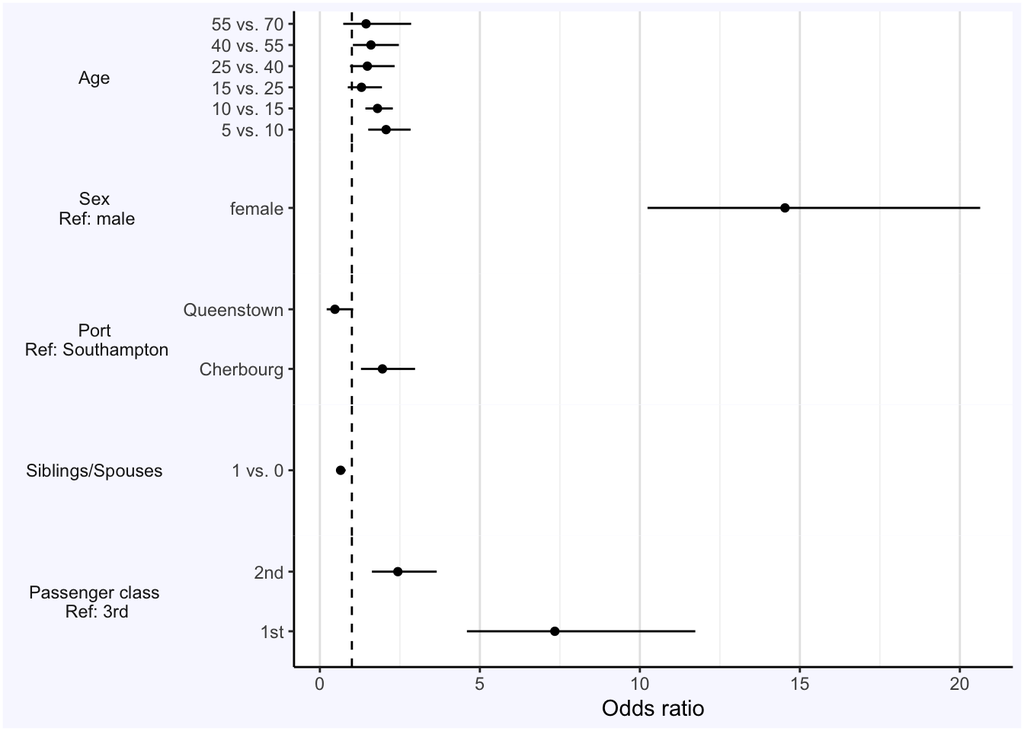

```r
bind_rows(
  rms.sum.table3(summary = summary(t3.mod, age = c(70, 55)), trib.cols.rms, raw = TRUE) ,
rms.sum.table3(summary = summary(t3.mod, age = c(55, 40)), trib.cols.rms, raw = TRUE) ) %>%
  bind_rows(.,
            rms.sum.table3(summary = summary(t3.mod, age = c(40, 25)), trib.cols.rms, raw = TRUE)) %>%
    bind_rows(.,
            rms.sum.table3(summary = summary(t3.mod, age = c(25, 15)), trib.cols.rms, raw = TRUE)) %>%
      bind_rows(.,
            rms.sum.table3(summary = summary(t3.mod, age = c(15, 10)), trib.cols.rms, raw = TRUE)) %>%
        bind_rows(.,
            rms.sum.table3(summary = summary(t3.mod, age = c(10, 5)), trib.cols.rms, raw = TRUE)) %>%
  distinct() %>% mutate(across(where(is.numeric), as.numeric)) %>%
  mutate(m = as.numeric(highc)) %>%
  arrange(level, m, highc) %>%
  mutate(axis = fct_inorder(axis) ) %>%
    ggplot(., aes(x = effect, y = axis)) + geom_point() +
    geom_errorbarh(aes(xmin = conf.low, xmax = conf.high), height = 0) +
    theme_classic() +
    geom_vline(xintercept = 1, linetype = 2) +
    labs(x = "Hazard ratio", y = NULL) +
    facet_grid(facet~., scales = "free_y", switch = "y")+
    theme(strip.text.y.left = element_text(angle = 0))+
    theme(strip.background  = element_blank()) +
    theme(panel.spacing.y = unit(0,"line")) +
    theme(strip.placement = 'outside') +
    theme(panel.grid.major.x = element_line(colour = "gray90"),
          panel.grid.minor.x = element_line(colour = "gray95",
                                            size = 0.3),
          plot.background = element_rect(fill = "ghostwhite", size = 1.3)) +
    theme(plot.caption = element_text(size = 7, hjust = 0))+
  labs(x = "Odds ratio")
```

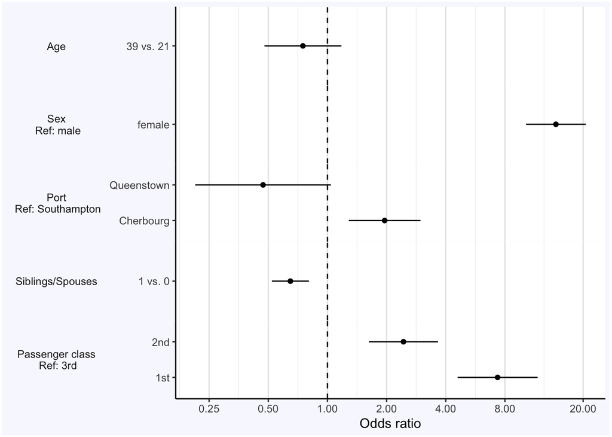

```r
rms.forest.plot(summary(t3.mod), trib.cols.rms) +
  scale_x_continuous(trans='log', breaks = c(0.25, 0.5, 1, 2, 4, 8, 20))+
  labs(x = "Odds ratio")
```

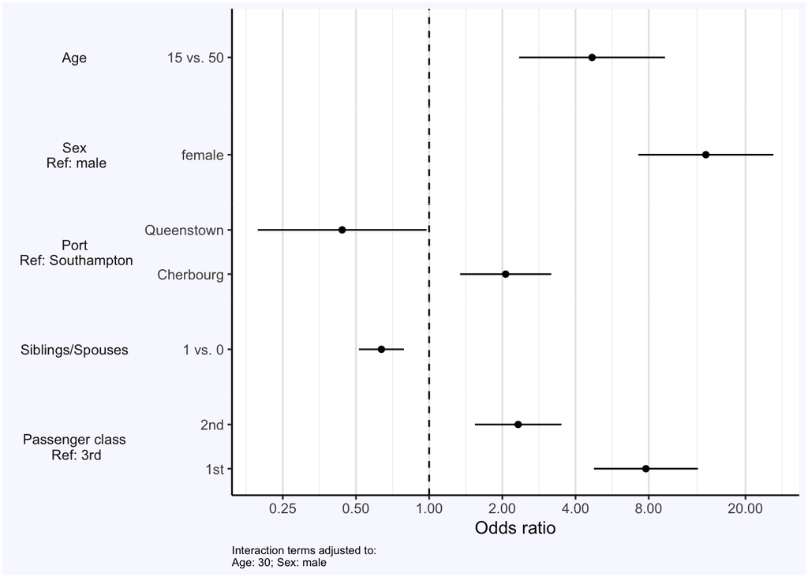

```r
rms.forest.plot(summary(t3.mod.int, age = c(50, 30, 15)), trib.cols.rms) +
  scale_x_continuous(trans='log', breaks = c(0.25, 0.5, 1, 2, 4, 8, 20)) +
  labs(x = "Odds ratio")
```

## 6.3 Interaction contrasts

### 6.3.1 expand.int and int.react

```r
t3_int <- expand.int(seq(10, 70, 10), c("male", "female"), "age", "sex", t3.mod)

int.react(t3_int)
```

| a1 | b1 | a2 | b2 | Effect | Lower.0.95 | Upper.0.95 | p |
| --- | --- | --- | --- | --- | --- | --- | --- |
| 10 | female | 10 | male | 14.54 | 10.24 | 20.64 | < 1e-04 |
| 10 | male | 10 | female | 0.07 | 0.05 | 0.1 | < 1e-04 |
| 20 | female | 20 | male | 14.54 | 10.24 | 20.64 | < 1e-04 |
| 20 | male | 20 | female | 0.07 | 0.05 | 0.1 | < 1e-04 |
| 30 | female | 30 | male | 14.54 | 10.24 | 20.64 | < 1e-04 |
| 30 | male | 30 | female | 0.07 | 0.05 | 0.1 | < 1e-04 |
| 40 | female | 40 | male | 14.54 | 10.24 | 20.64 | < 1e-04 |
| 40 | male | 40 | female | 0.07 | 0.05 | 0.1 | < 1e-04 |
| 50 | female | 50 | male | 14.54 | 10.24 | 20.64 | < 1e-04 |
| 50 | male | 50 | female | 0.07 | 0.05 | 0.1 | < 1e-04 |

[output cut: 172 more lines]

### 6.3.2 int.tile.plot

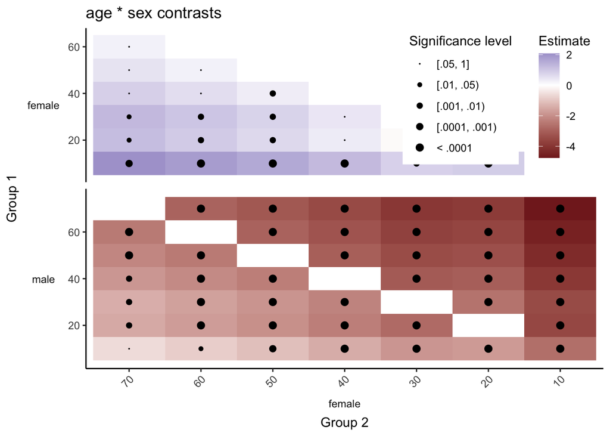

```r
int.tile.plot(t3_int, "age", "sex") +labs(fill = "Estimate")
```

# 7 Appendix

## 7.1 archive and changelog

```r
    load("/Users/joshdeclercq/Documents/GitHub/VUMisC/archive/t3/archive_summary_t3.rda")
    ad0 <- archive_details # expected 1 row - yes

changelog2(t3, "id") ## expected no action - yes
archive(t3) ## expected save new data - yes
archive(t3) ## expect no action- yes

    load("/Users/joshdeclercq/Documents/GitHub/VUMisC/archive/t3/archive_summary_t3.rda")
    ad <- archive_details # expected 2 row - yes

changelog2(t3, "id")  ##expect new log - yes

    load("/Users/joshdeclercq/Documents/GitHub/VUMisC/archive/t3/archive_summary_t3.rda")
    ad2 <- archive_details# expected 2 row - yes

archive(t3) ## expect no action - yes

load("/Users/joshdeclercq/Documents/GitHub/VUMisC/archive/t3/archive_summary_t3.rda")
ad3 <- archive_details # expected 2 row - yes


t3 %<>% mutate(z = 11, w = 12)
Sys.sleep(1)
changelog2(t3, "id") ## expected no action - yes

load("/Users/joshdeclercq/Documents/GitHub/VUMisC/archive/t3/archive_summary_t3.rda")
ad4 <- archive_details ##expected 2 rows - yes


archive(t3) ## expect new save - yes
load("/Users/joshdeclercq/Documents/GitHub/VUMisC/archive/t3/archive_summary_t3.rda")
ad5 <- archive_details # expect 3 rows - yes

changelog2(t3, "id") # expect new log  - yes

load("/Users/joshdeclercq/Documents/GitHub/VUMisC/archive/t3/archive_summary_t3.rda")
ad6 <- archive_details # expect 3 rows - yes


archive(t3) ## expect no action - yes

load("/Users/joshdeclercq/Documents/GitHub/VUMisC/archive/t3/archive_summary_t3.rda")
ad7 <- archive_details # expect 3 rows - ys


changelog2(t3, "id")
t3 %<>% mutate(z = NULL, a = "b")
Sys.sleep(1)
changelog2(t3, "id")
archive(t3)
archive(t3)
t3 %<>% mutate(y = 122, w = 293, z = 111, a = "w")
Sys.sleep(1)
changelog2(t3, "id")
archive(t3)


load("/Users/joshdeclercq/Documents/GitHub/VUMisC/archive/t3/archive_summary_t3.rda")
# ad <- archive_details
archive_details; ad

## For LATER -- why is changelog impacting archive???

load("/Users/joshdeclercq/Documents/GitHub/VUMisC/archive/t3/changelog_output_t3.rda")
changelog_output$diffs_by_var
```

## 7.2 get_toc

```r
get_toc("JDmisc.qmd") %>% j.reactable(., csv.file = "JDmisc toc")
```

| order | section | title |
| --- | --- | --- |
| 1 | 1 | Objective |
| 2 | 1.1 | Background |
| 3 | 1.2 | Goals |
| 4 | 1.3 | Data |
| 5 | 2 | Labels |
| 6 | 2.1 | Clear labels |
| 7 | 2.2 | Adding labels |
| 8 | 2.3 | Collect labels |
| 9 | 2.4 | Removing labels |
| 10 | 2.5 | Adding labels back |

[output cut: 23 more lines]

| package | version | n | funs |
| --- | --- | --- | --- |
| .GlobalEnv | NA | 24 | archive, changelog2, clear.label.class, clear.labels, collect.labels, date_dists, expand.int, get_toc, int.react, int.tile.plot, j.label5, j.reactable, j.trib, jgt, jgtt, label_factor, recode_factor, … |
| ggplot2 | 3.4.2 | 17 | aes, element_blank, element_line, element_rect, element_text, facet_grid, facet_wrap, geom_errorbarh, geom_histogram, geom_point, geom_vline, ggplot, labs, scale_x_continuous, theme, theme_classic, un… |
| base | 4.3.0 | 15 | Sys.sleep, as.Date, as.character, as.numeric, c, floor, ifelse, is.na, load, names, nrow, options, require, seq, summary |
| dplyr | 1.1.4 | 11 | %>%, across, arrange, bind_rows, distinct, mutate, n, recode_factor, select, tribble, where |
| plotly | 4.10.2 | 5 | %>%, arrange, distinct, mutate, select |
| rms | 6.7.1 | 4 | datadist, ggplot, lrm, rcs |
| stats | 4.3.0 | 4 | anova, na.omit, rcauchy, rnorm |
| gtsummary | 1.7.1 | 3 | %>%, mutate, select |
| tidyr | 1.3.0 | 3 | %>%, pivot_longer, tribble |
|  | NA | 2 | copy_labels, source_url |
| forcats | 1.0.0 | 2 | %>%, fct_inorder |
| lubridate | 1.9.3 | 2 | days, ymd |
| magrittr | 2.0.3 | 2 | %<>%, %>% |
| tibble | 3.2.1 | 2 | %>%, tribble |
| Hmisc | 5.1.0 | 1 | getHdata |
| labelVector | 0.1.2 | 1 | set_label |
| utils | 4.3.0 | 1 | head |

Current as of 2024-02-02 15:43:12.507584